# 1. Data warehouse:

- Read the CSV file.

```python
import numpy as np
import pandas as pd
import matplotlib.pyplot as plt
import seaborn as sns
df = pd.read_csv('DS+-+Part3+-+CompanyX_EU.csv') #importing the csv file as a Pandas data frame
df.head()
```

|  | Startup | Product | Funding | Event | Result | OperatingState |
| --- | --- | --- | --- | --- | --- | --- |
| 0 | 2600Hz | 2600hz.com | NaN | Disrupt SF 2013 | Contestant | Operating |
| 1 | 3DLT | 3dlt.com | $630K | Disrupt NYC 2013 | Contestant | Closed |
| 2 | 3DPrinterOS | 3dprinteros.com | NaN | Disrupt SF 2016 | Contestant | Operating |
| 3 | 3Dprintler | 3dprintler.com | $1M | Disrupt NY 2016 | Audience choice | Operating |
| 4 | 42 Technologies | 42technologies.com | NaN | Disrupt NYC 2013 | Contestant | Operating |

# 2. Data exploration:

- Check the datatypes of each attribute.

```python
df.dtypes #Checking datatype of each attribute
```

```
Startup           object
Product           object
Funding           object
Event             object
Result            object
OperatingState    object
dtype: object
```

- Check for null values in the attributes.

```python
df.isnull().sum() #Checking null values in each attribute
```

```
Startup             0
Product             6
Funding           214
Event               0
Result              0
OperatingState      0
dtype: int64
```

```python
df.info() #Alternatively info method can be used to get data type and non-null count in each attribute
```

```
<class 'pandas.core.frame.DataFrame'>
RangeIndex: 662 entries, 0 to 661
Data columns (total 6 columns):
 #   Column          Non-Null Count  Dtype
---  ------          --------------  -----
 0   Startup         662 non-null    object
 1   Product         656 non-null    object
 2   Funding         448 non-null    object
 3   Event           662 non-null    object
 4   Result          662 non-null    object
 5   OperatingState  662 non-null    object
dtypes: object(6)
memory usage: 31.2+ KB
```

# 3. Data preprocessing & visualisation:

- Drop the null values

```python
df = df.dropna() #Using dropna method to remove the rows with null values
```

```python
df.info()
```

```
<class 'pandas.core.frame.DataFrame'>
Int64Index: 446 entries, 1 to 661
Data columns (total 6 columns):
 #   Column          Non-Null Count  Dtype
---  ------          --------------  -----
 0   Startup         446 non-null    object
 1   Product         446 non-null    object
 2   Funding         446 non-null    object
 3   Event           446 non-null    object
 4   Result          446 non-null    object
 5   OperatingState  446 non-null    object
dtypes: object(6)
memory usage: 24.4+ KB
```

```python
df.isnull().sum() #checking null values again after dropping null values
```

```
Startup           0
Product           0
Funding           0
Event             0
Result            0
OperatingState    0
dtype: int64
```

- Convert the ‘Funding’ features to a numerical value.

```python
df['FundingTemp'] = df['Funding'].str.replace(r'$', '') #Removing '$' symbol and remaining characters in new column FundingTemp

df['FundingPart1'] = df['FundingTemp'].str[:-1] #Slicing all the characters (numeric) except the last non-numeroc character and storing as a separate column

df['FundingPart2'] = df['FundingTemp'].str[-1] #Slicing the last non-numeric character (K,M,B) and storing as a separate column

#Converting each non-numeric character in FundingPart2 column to equivalent numeric values and saving it as int
df['FundingPart2'] = df['FundingPart2'].replace({'K': '1000', 'M': '1000000', 'B': '1000000000'}).astype(int)

df['FundingPart1'] = df['FundingPart1'].astype(float) #Converting FundingPart1 column to float data type

#Multiplying FundingPart1 and FundingPart2 and saving it in new column FundingNum
df['FundingNum'] = df['FundingPart1']*df['FundingPart2']

df['FundingNum'] = df['FundingNum'].astype(int) #Converting FundingNum column to int data type

#Removing unnecessary columns
df.drop('FundingTemp', axis=1, inplace=True)
df.drop('FundingPart1', axis=1, inplace=True)
df.drop('FundingPart2', axis=1, inplace=True)

df[['Funding', 'FundingNum']]
```

|  | Funding | FundingNum |
| --- | --- | --- |
| 1 | $630K | 630000 |
| 3 | $1M | 1000000 |
| 5 | $19.3M | 19300000 |
| 6 | $29M | 29000000 |
| 10 | $1.8M | 1800000 |
| ... | ... | ... |
| 657 | $8M | 8000000 |
| 658 | $1M | 1000000 |
| 659 | $223M | 223000000 |
| 660 | $3.4M | 3400000 |
| 661 | $31.5M | 31500000 |

446 rows × 2 columns

```python
df.head()
```

|  | Startup | Product | Funding | Event | Result | OperatingState | FundingNum |
| --- | --- | --- | --- | --- | --- | --- | --- |
| 1 | 3DLT | 3dlt.com | $630K | Disrupt NYC 2013 | Contestant | Closed | 630000 |
| 3 | 3Dprintler | 3dprintler.com | $1M | Disrupt NY 2016 | Audience choice | Operating | 1000000 |
| 5 | 5to1 | 5to1.com | $19.3M | TC50 2009 | Contestant | Acquired | 19300000 |
| 6 | 8 Securities | 8securities.com | $29M | Disrupt Beijing 2011 | Finalist | Operating | 29000000 |
| 10 | AdhereTech | adheretech.com | $1.8M | Hardware Battlefield 2014 | Contestant | Operating | 1800000 |

- Plot box plot for funds in million.

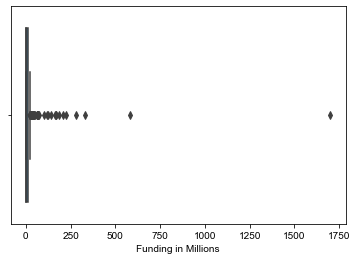

```python
import warnings
warnings.filterwarnings("ignore")
sns.boxplot(df.FundingNum/1000000).set(xlabel='Funding in Millions')
import matplotlib.pyplot as plt
sns.set(rc={'figure.figsize':(20,15)})
#Insight - The data in funding column seems heavily right skewed with many outliers. That is few companies have very high funding compared to the rest
```

```
[Text(0.5, 0, 'Funding in Millions')]
```

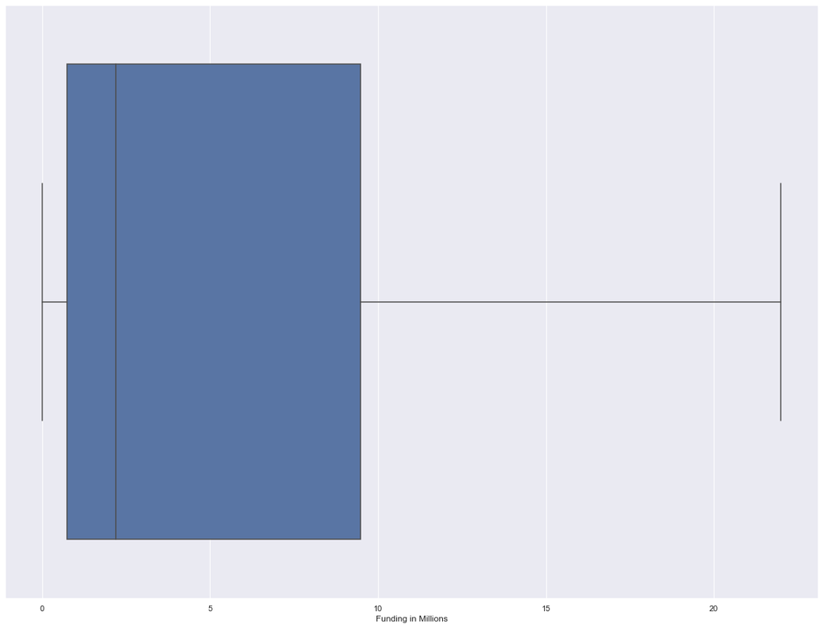

```python
#Boxplot without outliers
sns.boxplot(df.FundingNum/1000000, showfliers = False).set(xlabel='Funding in Millions')
```

- Get the lower fence from the box plot

```python
# Lower whisker or fence can be calculated as First Quartile(Q1)-(1.5*IQR) or the minimum value in the dataset whichever is higher.
IQR = df['FundingNum'].quantile(0.75)-df['FundingNum'].quantile(0.25) #Inter Quartile Range
Min = df['FundingNum'].min() #Minimum value in FundingNum column
Lower_Fence = max(Min, ((df['FundingNum'].quantile(0.25))-1.5*IQR)) #Finding the higher of the two values
print('The value of lower fence is', Lower_Fence, 'Dollars')
```

```
The value of lower fence is 5000 Dollars
```

- Check number of outliers greater than upper fence

```python
#Calculating Upper Fence
Max = df['FundingNum'].max() #Maximum value in FindingNum column
Upper_Fence = min(Max, ((df['FundingNum'].quantile(0.75))+1.5*IQR)).astype(int) #Calculating upper fence
print('The value of upper fence is', Upper_Fence, 'Dollars')
print('The number of outliers greater than the upper fence is', df[df['FundingNum']>Upper_Fence].shape[0])
```

```
The value of upper fence is 22569625 Dollars
The number of outliers greater than the upper fence is 60
```

- Drop the values that are greater than upper fence

```python
print(df.shape[0])
df.drop(df[df['FundingNum']>Upper_Fence].index, axis=0, inplace=True) #Drop rows that have funding higher than the upper fence
print(df.shape[0])
```

```
446
386
```

- Plot the box plot after dropping the values

```
[Text(0.5, 0, 'Funding in Millions')]
```

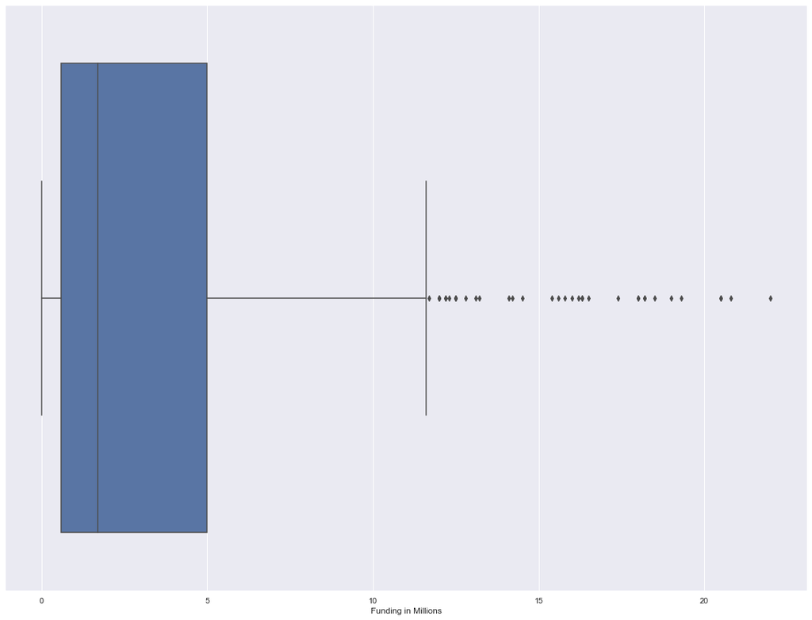

```python
sns.boxplot(df.FundingNum/1000000).set(xlabel='Funding in Millions')
#Insight - The data is still right skewed, but to a considerably lesser degree
```

- Check frequency of the status features classes

```python
df['OperatingState'].value_counts() #Showing the frequency using frequency table
```

```
Operating    275
Closed        56
Acquired      55
Name: OperatingState, dtype: int64
```

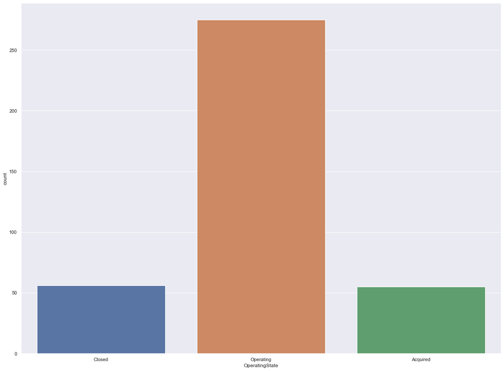

```python
sns.countplot(df['OperatingState']) #Showing the frequency using count plot
#Insight - Most of the startups are operating and few have even been acquired which points to the success of the startups
```

- Plot a distribution plot for Funds in million.

```
[Text(0.5, 0, 'Funding in Millions'), Text(0, 0.5, 'Number of companies')]
```

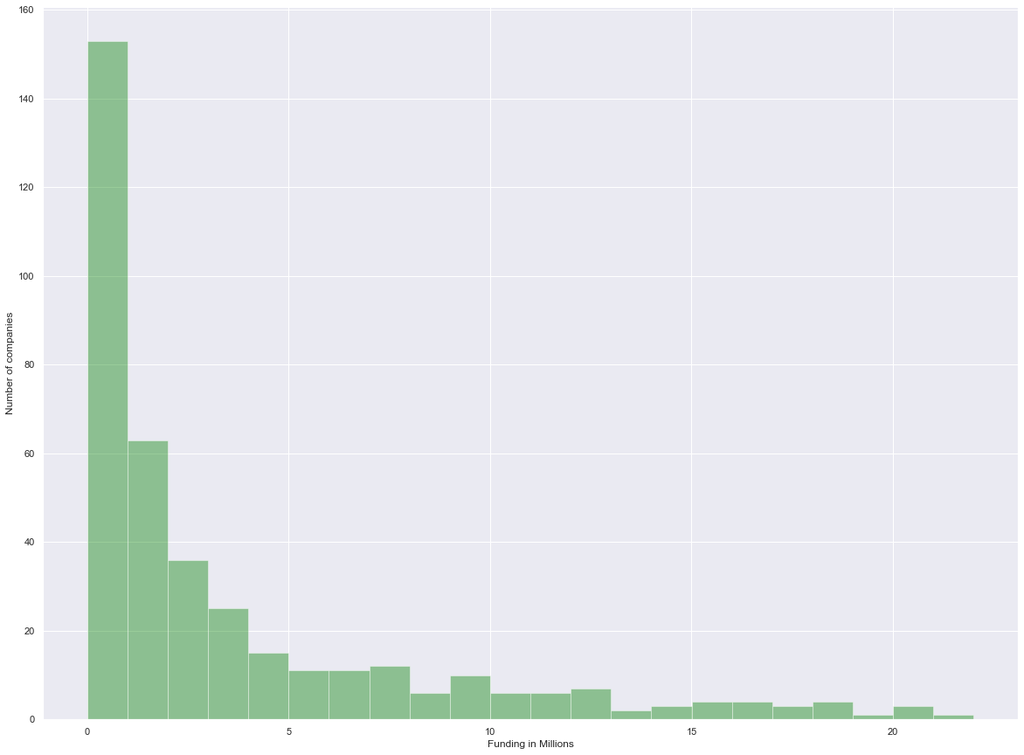

```python
sns.distplot(df['FundingNum']/1000000, kde=False, color='green', bins=22).set(xlabel='Funding in Millions', ylabel = 'Number of companies')
#Insight - Most startups have low funding, less than 2 million dollars
```

- Plot distribution plots for companies still operating and companies that closed.

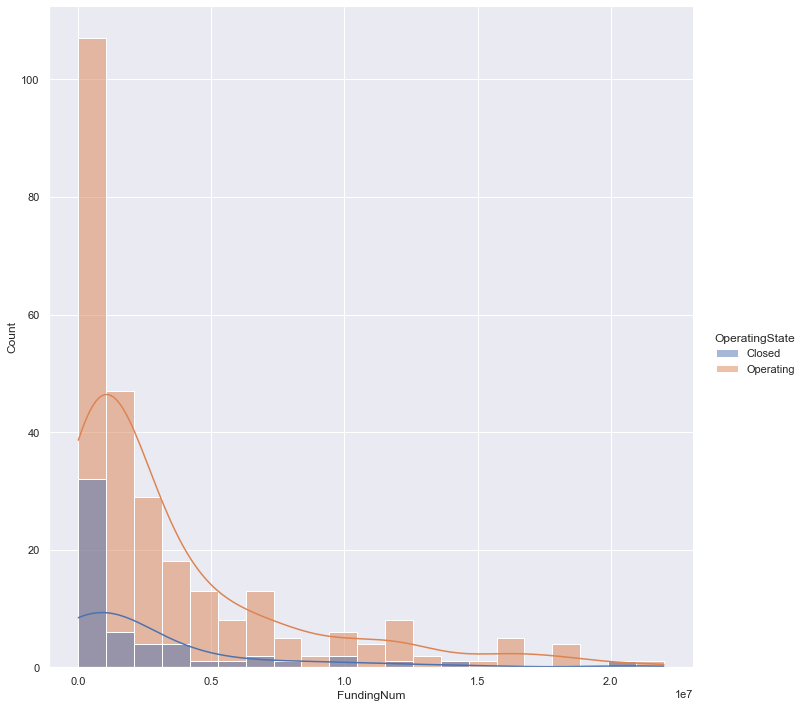

```python
#Plotting the distribution of funding over companies operating and closed
dfoc = df[(df['OperatingState']=='Operating')|(df['OperatingState']=='Closed')]
sns.displot(data=dfoc, x='FundingNum', hue='OperatingState', kde=True, height=10, aspect=1)
```